# Yoav data: cell ordering, non-ribosomal genes

Kushal K Dey

November 15, 2015

```r
library(qtlcharts)
library(CountClust)
library(parallel)
library(cellcycleR)
library(data.table)
library(binhf)
library(vioplot)
library(limma)
library(readxl)
library(mygene)
library(knitr)
```

## Background

On applying the cellcycleR method on Yoav data across all genes, the cellcycleR seemed to be picking up the ribosomal proteins. These genes also do not seem to be separating out the S phase and the M phase very clearly. On the other hand, when only the annotated cell cycle genes are used, they seem to be picking up cell phase information, cell cycle genes associated with CDC, cyclin etc are captured. The idea now is to see that if we remove all the genes related to ribosomal proteins, are we capturing these more meaningful cell phase specific genes?

## Removing the ribosomal genes

```r
setwd('/Users/kushal/Documents/singleCell-method/project/analysis')
colnames <- colnames(read.table("../data/batch_removed_counts_all_genes.txt"));
molecules_single <- data.frame(fread("../data/batch_removed_counts_all_genes.txt"), row.names = 1);
colnames(molecules_single) <- colnames
cycle_counts_data <- molecules_single;
dim(cycle_counts_data)
```

```
## [1]   578 17084
```

```r
cycle_voom_data <- voom(cycle_counts_data)$E;
cycle_data_norm <- apply(cycle_voom_data,2,function(x)  return (x-mean(x))/sd(x))
celltime_levels <- 100;
cycle_data_norm <- cycle_data_norm[, which(colSums(cycle_data_norm)!=0)]

dim(cycle_data_norm)
```

```
## [1]   578 16860
```

Next we use the **mygene** package to annotate all the genes and save the output as a rda file.

```r
out <- queryMany(colnames(cycle_data_norm),  scopes="ensembl.gene", fields=c("name","summary"), species="human");

query_names <- out$query;
unique_query_names <- unique(query_names);

annotate_genes <- out[match(unique_query_names, query_names),];
save(annotate_genes, file="../rdas/annotate_all_genes.rda")
```

## Filtering out the ribosomal genes

```r
annotate_genes <- get(load("../rdas/annotate_all_genes.rda"));
filter1 <- grep("ribo", annotate_genes$name)
filter2 <- grep("mitochondrial", annotate_genes$name)
filter <- unique(c(filter1,filter2))

annotate_genes_filtered <- annotate_genes[-filter,];
gene_names_filtered <- annotate_genes_filtered$query;

labeling_indices <- match(gene_names_filtered, colnames(cycle_data_norm))
cycle_data_norm <- cycle_data_norm[,labeling_indices];
```

The cell phases as assigned using Macosko method

```r
cell_phases <- as.vector(as.matrix(read.table("../data/cell_phase_vector_yoav.txt")));
```

## apply cellcycleR on the filtered non-ribosomal non-mitochondrial genes

```r
out <- cell_ordering_class(cycle_data_norm, celltime_levels = 100, num_iter=100, save_path="../rdas/cell_order_ipsc_non_ribosomal.rda")
```

We ran the method above once already (took around 30 minutes) and now we just load the output.

```r
out <- get(load(file="../rdas/cell_order_ipsc_non_ribosomal.rda"));
cell_order_full <- cell_ordering_full(out$signal_intensity, dim(cycle_data_norm)[2])
```

We look at the plots of the amplitudes, phases and the non signal variation of the genes.

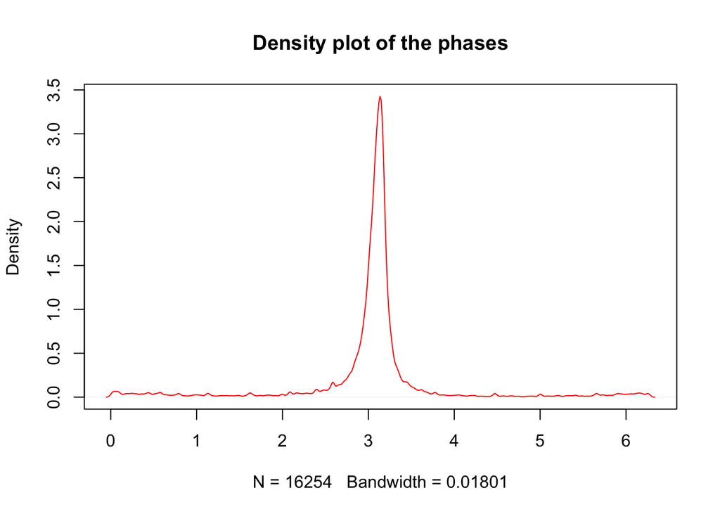

```r
amp_genes <- out$amp;
sd_genes <- out$sigma;
phi_genes <- out$phi;

plot(density(phi_genes), col="red", main="Density plot of the phases")
```

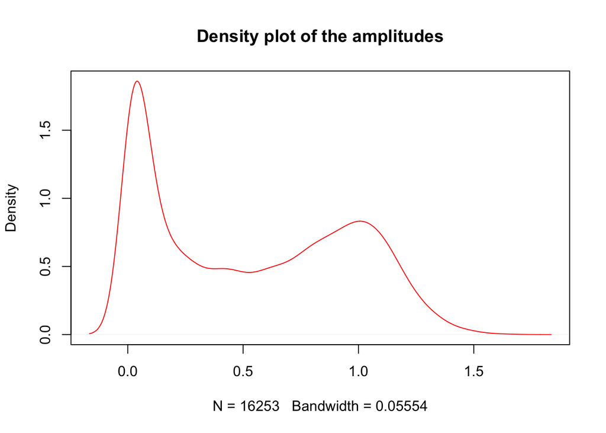

```r
plot(density(amp_genes[-which.max(amp_genes)]), col="red", main="Density plot of the amplitudes")
```

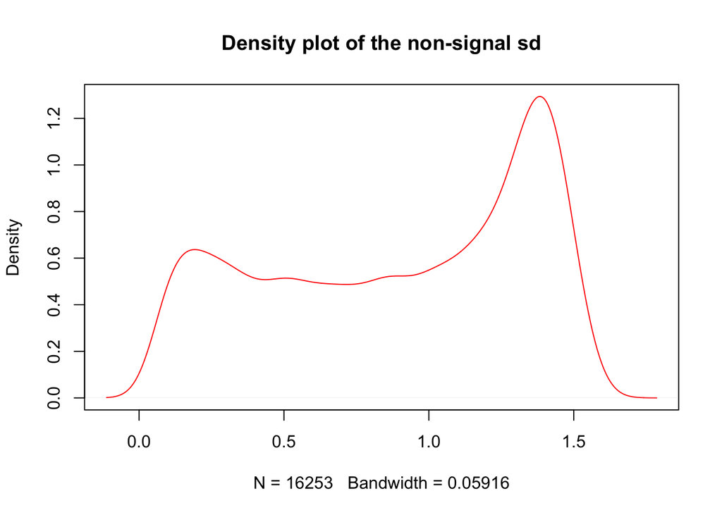

```r
plot(density(sd_genes[-which.max(sd_genes)]), col="red", main="Density plot of the non-signal sd")
```

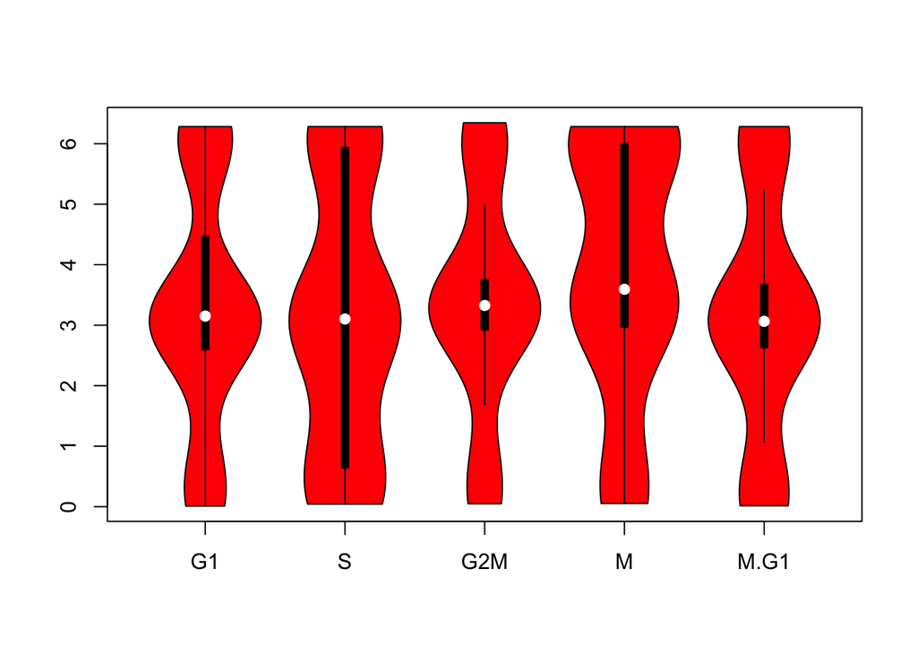

```r
vioplot(cell_order_full[which(cell_phases=="G1.S")],
        cell_order_full[which(cell_phases=="S")],
        cell_order_full[which(cell_phases=="G2.M")],
        cell_order_full[which(cell_phases=="M")],
        cell_order_full[which(cell_phases=="M.G1")],
        names=c("G1","S","G2M","M","M.G1"),
        col="red")
```

We extract the genes with high SNR - these are more likely to be sinusoidal.

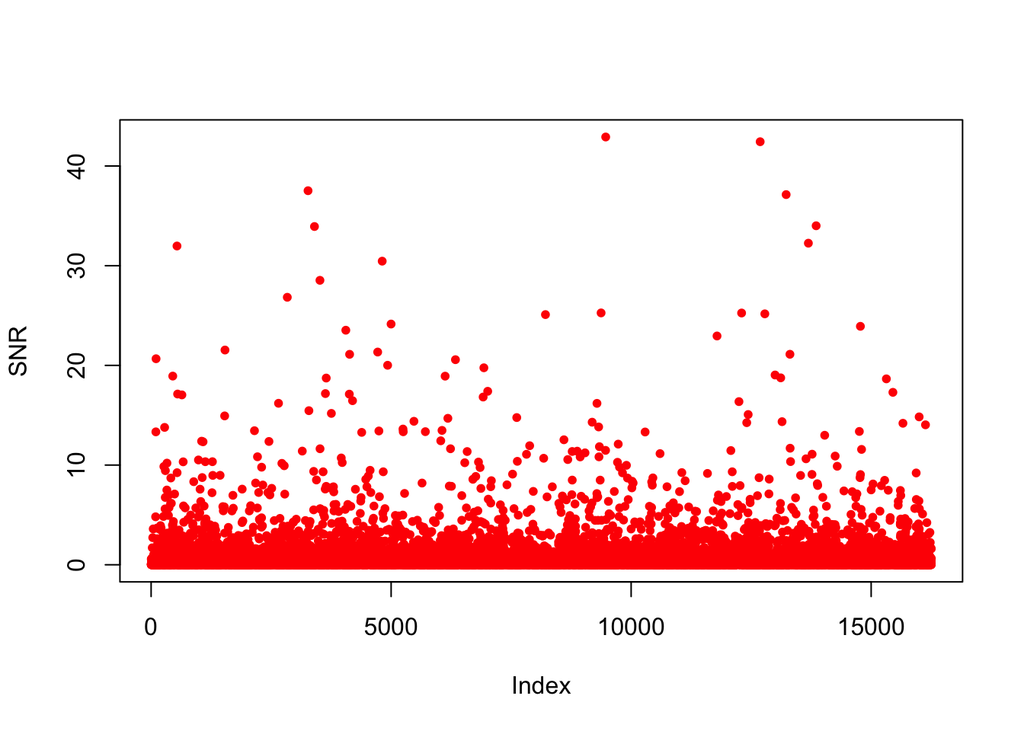

```r
ESS <- amp_genes^2; RSS <- sd_genes^2

SNR <- ESS/RSS;

plot(SNR, col="red", pch=20, lwd=1)
```

```r
top_genes <- which(SNR > 10);
```

Next we plot the qtlcharts for these top sinusoidal genes and see if their patterns are indeed sinusoidal or not.

```r
iplotCurves(t(cycle_data_norm[order(cell_order_full),top_genes]))
```

```
## Set screen size to height=700 x width=1000
```

[interactive chart not shown]

## Gene Annotations

We perform gene annotations on the highly sinusoidal genes obtained from among the non ribosomal genes and see if they have cell phase related functionalities or not.

```r
sinusoidal_gene_names <- colnames(cycle_data_norm);
imp_genes <- sinusoidal_gene_names[order(SNR, decreasing=TRUE)]
top_genes_100 <- imp_genes[1:100];
```

We annotate these genes using the **mygene** package and report them in a tabular format.

```r
out <- queryMany(top_genes_100,  scopes="ensembl.gene", fields=c("name","summary"), species="human");
```

```
## Finished
## Pass returnall=TRUE to return lists of duplicate or missing query terms.
```

```r
kable(as.data.frame(out))
```

| name | X_id | query | summary | notfound |
| --- | --- | --- | --- | --- |
| prothymosin alpha-like | 728026 | ENSG00000187514 | NA | NA |
| prothymosin, alpha | 5757 | ENSG00000187514 | NA | NA |
| nucleophosmin (nucleolar phosphoprotein B23, numatrin) | 4869 | ENSG00000181163 | This gene encodes a phosphoprotein which moves between the nucleus and the cytoplasm. The gene product is thought to be involved in several processes including regulation of the ARF/p53 pathway. A num… | NA |
| glyceraldehyde-3-phosphate dehydrogenase | 2597 | ENSG00000111640 | This gene encodes a member of the glyceraldehyde-3-phosphate dehydrogenase protein family. The encoded protein has been identified as a moonlighting protein based on its ability to perform mechanistic… | NA |
| heat shock protein 90kDa alpha (cytosolic), class B member 1 | 3326 | ENSG00000096384 | This gene encodes a member of the heat shock protein 90 family; these proteins are involved in signal transduction, protein folding and degradation and morphological evolution. This gene encodes the c… | NA |
| peptidylprolyl isomerase A (cyclophilin A) | 5478 | ENSG00000196262 | This gene encodes a member of the peptidyl-prolyl cis-trans isomerase (PPIase) family. PPIases catalyze the cis-trans isomerization of proline imidic peptide bonds in oligopeptides and accelerate the … | NA |
| lactate dehydrogenase B | 3945 | ENSG00000111716 | This gene encodes the B subunit of lactate dehydrogenase enzyme, which catalyzes the interconversion of pyruvate and lactate with concomitant interconversion of NADH and NAD+ in a post-glycolysis proc… | NA |
| actin, beta | 60 | ENSG00000075624 | This gene encodes one of six different actin proteins. Actins are highly conserved proteins that are involved in cell motility, structure, and integrity. This actin is a major constituent of the contr… | NA |
| peroxiredoxin 1 | 5052 | ENSG00000117450 | This gene encodes a member of the peroxiredoxin family of antioxidant enzymes, which reduce hydrogen peroxide and alkyl hydroperoxides. The encoded protein may play an antioxidant protective role in c… | NA |
| heat shock protein 90kDa alpha (cytosolic), class A member 1 | 3320 | ENSG00000080824 | The protein encoded by this gene is an inducible molecular chaperone that functions as a homodimer. The encoded protein aids in the proper folding of specific target proteins by use of an ATPase activ… | NA |
| tubulin, alpha 1b | 10376 | ENSG00000123416 | NA | NA |
| glutathione S-transferase pi 1 | 2950 | ENSG00000084207 | Glutathione S-transferases (GSTs) are a family of enzymes that play an important role in detoxification by catalyzing the conjugation of many hydrophobic and electrophilic compounds with reduced gluta… | NA |
| X-ray repair complementing defective repair in Chinese hamster cells 5 (double-strand-break rejoining) | 7520 | ENSG00000079246 | The protein encoded by this gene is the 80-kilodalton subunit of the Ku heterodimer protein which is also known as ATP-dependant DNA helicase II or DNA repair protein XRCC5. Ku is the DNA-binding comp… | NA |
| cytochrome c oxidase subunit VIIc | 1350 | ENSG00000127184 | Cytochrome c oxidase (COX), the terminal component of the mitochondrial respiratory chain, catalyzes the electron transfer from reduced cytochrome c to oxygen. This component is a heteromeric complex … | NA |
| guanine nucleotide binding protein (G protein), beta polypeptide 2-like 1 | 10399 | ENSG00000204628 | NA | NA |
| ferritin, light polypeptide | 2512 | ENSG00000087086 | This gene encodes the light subunit of the ferritin protein. Ferritin is the major intracellular iron storage protein in prokaryotes and eukaryotes. It is composed of 24 subunits of the heavy and ligh… | NA |
| small EDRK-rich factor 2 | 10169 | ENSG00000140264 | NA | NA |
| poly(A) binding protein, cytoplasmic 1 | 26986 | ENSG00000070756 | This gene encodes a poly(A) binding protein. The protein shuttles between the nucleus and cytoplasm and binds to the 3’ poly(A) tail of eukaryotic messenger RNAs via RNA-recognition motifs. The bindin… | NA |
| RAN, member RAS oncogene family | 5901 | ENSG00000132341 | RAN (ras-related nuclear protein) is a small GTP binding protein belonging to the RAS superfamily that is essential for the translocation of RNA and proteins through the nuclear pore complex. The RAN … | NA |
| H2A histone family, member Z | 3015 | ENSG00000164032 | Histones are basic nuclear proteins that are responsible for the nucleosome structure of the chromosomal fiber in eukaryotes. Nucleosomes consist of approximately 146 bp of DNA wrapped around a histon… | NA |
| H3 histone, family 3A | 3020 | ENSG00000163041 | Histones are basic nuclear proteins that are responsible for the nucleosome structure of the chromosomal fiber in eukaryotes. Two molecules of each of the four core histones (H2A, H2B, H3, and H4) for… | NA |
| SRA stem-loop interacting RNA binding protein | 81892 | ENSG00000119705 | Steroid receptor RNA activator (SRA, or SRA1; MIM 603819) is a complex RNA molecule containing multiple stable stem-loop structures that functions in coactivation of nuclear receptors. SLIRP interacts… | NA |
| eukaryotic translation elongation factor 1 alpha 1 | 1915 | ENSG00000156508 | This gene encodes an isoform of the alpha subunit of the elongation factor-1 complex, which is responsible for the enzymatic delivery of aminoacyl tRNAs to the ribosome. This isoform (alpha 1) is expr… | NA |
| high mobility group box 1 | 3146 | ENSG00000189403 | This gene encodes a protein that belongs to the High Mobility Group-box superfamily. The encoded non-histone, nuclear DNA-binding protein regulates transcription, and is involved in organization of DN… | NA |
| enolase 1, (alpha) | 2023 | ENSG00000074800 | This gene encodes alpha-enolase, one of three enolase isoenzymes found in mammals. Each isoenzyme is a homodimer composed of 2 alpha, 2 gamma, or 2 beta subunits, and functions as a glycolytic enzyme.… | NA |
| ubiquitin B | 7314 | ENSG00000170315 | This gene encodes ubiquitin, one of the most conserved proteins known. Ubiquitin has a major role in targeting cellular proteins for degradation by the 26S proteosome. It is also involved in the maint… | NA |
| signal recognition particle 14kDa (homologous Alu RNA binding protein) | 6727 | ENSG00000140319 | NA | NA |
| H3 histone, family 3B (H3.3B) | 3021 | ENSG00000132475 | Histones are basic nuclear proteins that are responsible for the nucleosome structure of the chromosomal fiber in eukaryotes. Two molecules of each of the four core histones (H2A, H2B, H3, and H4) for… | NA |
| tubulin, beta class I | 203068 | ENSG00000196230 | This gene encodes a beta tubulin protein. This protein forms a dimer with alpha tubulin and acts as a structural component of microtubules. Mutations in this gene cause cortical dysplasia, complex, wi… | NA |
| NADH dehydrogenase (ubiquinone) Fe-S protein 5, 15kDa (NADH-coenzyme Q reductase) | 4725 | ENSG00000168653 | This gene is a member of the NADH dehydrogenase (ubiquinone) iron-sulfur protein family. The encoded protein is a subunit of the NADH:ubiquinone oxidoreductase (complex I), the first enzyme complex in… | NA |

[output cut: 74 more lines]